# 1. Business Understanding

This data set was made with the intention to predict and prevent studen dropouts and failures in higher education. The data contains basic information about the student and their parents, including socio-economic and demographic information.

Using this data, we aim to identify factors that may be correlated to an increased probability of a student dropping out and/or failing out of college or university. It would also be useful to identify which factors may indicate a higher probability of student success. If the factors are something in the student's control, these results can be used by employees in higher education to help students who may be at a higher risk of leaving higher education prematurely. The results could also be used by various non-profits and tutoring companies to aid students who are high risk.

Colleges and universities could use this data to increase retention rates. SMU, specifically the Lyle School of Engineering, could utilize this data to make efforts in The Recruitment and Retention Office more effective.

## Measure of Reliability

https://ieeexplore.ieee.org/document/10056943

In this article, the researchers sought to predict student performance in higher education. In the literature review section, they referenced multiple other studies that had been done using machine learning. A few of those descriptions included the accuracy of the prediciton models used; in the first, the accuracy was 76.37-82.39%, and on the second, there was an accuracy of 74%. Based on these results, our prediction algorithm should have an accuracy of 75% or greater to be on par with other pre-existing machine learning models.

# 2. Data Understanding

## 2.1 Data Description

```python
import pandas as pd
import numpy as np

df = pd.read_csv('data.csv')

#remove unwanted columns
drop_columns = ['Previous qualification','Previous qualification (grade)','Admission grade','Daytime/evening attendance\t','Application mode', 'Application order','Tuition fees up to date', 'Curricular units 1st sem (credited)', 'Curricular units 1st sem (evaluations)', 'Curricular units 1st sem (approved)', 'Curricular units 1st sem (without evaluations)', 'Curricular units 2nd sem (credited)', 'Curricular units 2nd sem (evaluations)', 'Curricular units 2nd sem (approved)', 'Curricular units 2nd sem (without evaluations)', 'Age at enrollment', 'GDP', 'Inflation rate', 'Unemployment rate']
df = df.drop(drop_columns, axis=1)

#rename target column to 'Dropout'
df = df.rename(columns={'Target': 'Dropout'})

#replace content of 'Dropout' column to 0 and 1 from Graduate and Dropout respectively
df.Dropout.replace(['Graduate', 'Dropout'], [0, 1], inplace=True)
df.head()
```

|  | Marital status | Course | Nacionality | Mother's qualification | Father's qualification | Mother's occupation | Father's occupation | Displaced | Educational special needs | Debtor | Gender | Scholarship holder | International | Curricular units 1st sem (enrolled) | Curricular units 1st sem (grade) | Curricular units 2nd sem (enrolled) | Curricular units 2nd sem (grade) | Dropout |
| --- | --- | --- | --- | --- | --- | --- | --- | --- | --- | --- | --- | --- | --- | --- | --- | --- | --- | --- |
| 0 | 1 | 171 | 1 | 19 | 12 | 5 | 9 | 1 | 0 | 0 | 1 | 0 | 0 | 0 | 0.000000 | 0 | 0.000000 | 1 |
| 1 | 1 | 9254 | 1 | 1 | 3 | 3 | 3 | 1 | 0 | 0 | 1 | 0 | 0 | 6 | 14.000000 | 6 | 13.666667 | 0 |
| 2 | 1 | 9070 | 1 | 37 | 37 | 9 | 9 | 1 | 0 | 0 | 1 | 0 | 0 | 6 | 0.000000 | 6 | 0.000000 | 1 |
| 3 | 1 | 9773 | 1 | 38 | 37 | 5 | 3 | 1 | 0 | 0 | 0 | 0 | 0 | 6 | 13.428571 | 6 | 12.400000 | 0 |
| 4 | 2 | 8014 | 1 | 37 | 38 | 9 | 9 | 0 | 0 | 0 | 0 | 0 | 0 | 6 | 12.333333 | 6 | 13.000000 | 0 |

```python
#getting data types
df.info()
```

```
<class 'pandas.core.frame.DataFrame'>
RangeIndex: 4424 entries, 0 to 4423
Data columns (total 18 columns):
 #   Column                               Non-Null Count  Dtype
---  ------                               --------------  -----
 0   Marital status                       4424 non-null   int64
 1   Course                               4424 non-null   int64
 2   Nacionality                          4424 non-null   int64
 3   Mother's qualification               4424 non-null   int64
 4   Father's qualification               4424 non-null   int64
 5   Mother's occupation                  4424 non-null   int64
 6   Father's occupation                  4424 non-null   int64
 7   Displaced                            4424 non-null   int64
 8   Educational special needs            4424 non-null   int64
 9   Debtor                               4424 non-null   int64
 10  Gender                               4424 non-null   int64
 11  Scholarship holder                   4424 non-null   int64
 12  International                        4424 non-null   int64
 13  Curricular units 1st sem (enrolled)  4424 non-null   int64
 14  Curricular units 1st sem (grade)     4424 non-null   float64
 15  Curricular units 2nd sem (enrolled)  4424 non-null   int64
 16  Curricular units 2nd sem (grade)     4424 non-null   float64
 17  Dropout                              4424 non-null   object
dtypes: float64(2), int64(15), object(1)
memory usage: 622.2+ KB
```

The following table shows descriptions and the types of features in the dataset

```python
attr_des = pd.DataFrame();
attr_des['Features'] = df.columns
# Description taken directly from dataset website https://archive.ics.uci.edu/dataset/697/predict+students+dropout+and+academic+success
attr_des['Description'] = ['1 – single 2 – married 3 – widower 4 – divorced 5 – facto union 6 – legally separated',
                           '33 - Biofuel Production Technologies 171 - Animation and Multimedia Design 8014 - Social Service (evening attendance) 9003 - Agronomy 9070 - Communication Design 9085 - Veterinary Nursing 9119 - Informatics Engineering 9130 - Equinculture 9147 - Management 9238 - Social Service 9254 - Tourism 9500 - Nursing 9556 - Oral Hygiene 9670 - Advertising and Marketing Management 9773 - Journalism and Communication 9853 - Basic Education 9991 - Management (evening attendance)',
                            '1 - Portuguese; 2 - German; 6 - Spanish; 11 - Italian; 13 - Dutch; 14 - English; 17 - Lithuanian; 21 - Angolan; 22 - Cape Verdean; 24 - Guinean; 25 - Mozambican; 26 - Santomean; 32 - Turkish; 41 - Brazilian; 62 - Romanian; 100 - Moldova (Republic of); 101 - Mexican; 103 - Ukrainian; 105 - Russian; 108 - Cuban; 109 - Colombian',
                            '1 - Secondary Education - 12th Year of Schooling or Eq. 2 - Higher Education - Bachelor''s Degree 3 - Higher Education - Degree 4 - Higher Education - Master''s 5 - Higher Education - Doctorate 6 - Frequency of Higher Education 9 - 12th Year of Schooling - Not Completed 10 - 11th Year of Schooling - Not Completed 11 - 7th Year (Old) 12 - Other - 11th Year of Schooling 14 - 10th Year of Schooling 18 - General commerce course 19 - Basic Education 3rd Cycle (9th/10th/11th Year) or Equiv. 22 - Technical-professional course 26 - 7th year of schooling 27 - 2nd cycle of the general high school course 29 - 9th Year of Schooling - Not Completed 30 - 8th year of schooling 34 - Unknown 35 - Can''t read or write 36 - Can read without having a 4th year of schooling 37 - Basic education 1st cycle (4th/5th year) or equiv. 38 - Basic Education 2nd Cycle (6th/7th/8th Year) or Equiv. 39 - Technological specialization course 40 - Higher education - degree (1st cycle) 41 - Specialized higher studies course 42 - Professional higher technical course 43 - Higher Education - Master (2nd cycle) 44 - Higher Education - Doctorate (3rd cycle)',
                            '1 - Secondary Education - 12th Year of Schooling or Eq. 2 - Higher Education - Bachelor''s Degree 3 - Higher Education - Degree 4 - Higher Education - Master''s 5 - Higher Education - Doctorate 6 - Frequency of Higher Education 9 - 12th Year of Schooling - Not Completed 10 - 11th Year of Schooling - Not Completed 11 - 7th Year (Old) 12 - Other - 11th Year of Schooling 13 - 2nd year complementary high school course 14 - 10th Year of Schooling 18 - General commerce course 19 - Basic Education 3rd Cycle (9th/10th/11th Year) or Equiv. 20 - Complementary High School Course 22 - Technical-professional course 25 - Complementary High School Course - not concluded 26 - 7th year of schooling 27 - 2nd cycle of the general high school course 29 - 9th Year of Schooling - Not Completed 30 - 8th year of schooling 31 - General Course of Administration and Commerce 33 - Supplementary Accounting and Administration 34 - Unknown 35 - Can''t read or write 36 - Can read without having a 4th year of schooling 37 - Basic education 1st cycle (4th/5th year) or equiv. 38 - Basic Education 2nd Cycle (6th/7th/8th Year) or Equiv. 39 - Technological specialization course 40 - Higher education - degree (1st cycle) 41 - Specialized higher studies course 42 - Professional higher technical course 43 - Higher Education - Master (2nd cycle) 44 - Higher Education - Doctorate (3rd cycle)',
                            '0 - Student 1 - Representatives of the Legislative Power and Executive Bodies, Directors, Directors and Executive Managers 2 - Specialists in Intellectual and Scientific Activities 3 - Intermediate Level Technicians and Professions 4 - Administrative staff 5 - Personal Services, Security and Safety Workers and Sellers 6 - Farmers and Skilled Workers in Agriculture, Fisheries and Forestry 7 - Skilled Workers in Industry, Construction and Craftsmen 8 - Installation and Machine Operators and Assembly Workers 9 - Unskilled Workers 10 - Armed Forces Professions 90 - Other Situation 99 - (blank) 122 - Health professionals 123 - teachers 125 - Specialists in information and communication technologies (ICT) 131 - Intermediate level science and engineering technicians and professions 132 - Technicians and professionals, of intermediate level of health 134 - Intermediate level technicians from legal, social, sports, cultural and similar services 141 - Office workers, secretaries in general and data processing operators 143 - Data, accounting, statistical, financial services and registry-related operators 144 - Other administrative support staff 151 - personal service workers 152 - sellers 153 - Personal care workers and the like 171 - Skilled construction workers and the like, except electricians 173 - Skilled workers in printing, precision instrument manufacturing, jewelers, artisans and the like 175 - Workers in food processing, woodworking, clothing and other industries and crafts 191 - cleaning workers 192 - Unskilled workers in agriculture, animal production, fisheries and forestry 193 - Unskilled workers in extractive industry, construction, manufacturing and transport 194 - Meal preparation assistants',
                            '0 - Student 1 - Representatives of the Legislative Power and Executive Bodies, Directors, Directors and Executive Managers 2 - Specialists in Intellectual and Scientific Activities 3 - Intermediate Level Technicians and Professions 4 - Administrative staff 5 - Personal Services, Security and Safety Workers and Sellers 6 - Farmers and Skilled Workers in Agriculture, Fisheries and Forestry 7 - Skilled Workers in Industry, Construction and Craftsmen 8 - Installation and Machine Operators and Assembly Workers 9 - Unskilled Workers 10 - Armed Forces Professions 90 - Other Situation 99 - (blank) 101 - Armed Forces Officers 102 - Armed Forces Sergeants 103 - Other Armed Forces personnel 112 - Directors of administrative and commercial services 114 - Hotel, catering, trade and other services directors 121 - Specialists in the physical sciences, mathematics, engineering and related techniques 122 - Health professionals 123 - teachers 124 - Specialists in finance, accounting, administrative organization, public and commercial relations 131 - Intermediate level science and engineering technicians and professions 132 - Technicians and professionals, of intermediate level of health 134 - Intermediate level technicians from legal, social, sports, cultural and similar services 135 - Information and communication technology technicians 141 - Office workers, secretaries in general and data processing operators 143 - Data, accounting, statistical, financial services and registry-related operators 144 - Other administrative support staff 151 - personal service workers 152 - sellers 153 - Personal care workers and the like 154 - Protection and security services personnel 161 - Market-oriented farmers and skilled agricultural and animal production workers 163 - Farmers, livestock keepers, fishermen, hunters and gatherers, subsistence 171 - Skilled construction workers and the like, except electricians 172 - Skilled workers in metallurgy, metalworking and similar 174 - Skilled workers in electricity and electronics 175 - Workers in food processing, woodworking, clothing and other industries and crafts 181 - Fixed plant and machine operators 182 - assembly workers 183 - Vehicle drivers and mobile equipment operators 192 - Unskilled workers in agriculture, animal production, fisheries and forestry 193 - Unskilled workers in extractive industry, construction, manufacturing and transport 194 - Meal preparation assistants 195 - Street vendors (except food) and street service providers',
                            '1 – yes 0 – no',
                            '1 – yes 0 – no',
                            '1 – yes 0 – no',
                            '1 – male 0 – female',
                            '1 – yes 0 – no',
                            '1 – yes 0 – no',
                            'Number of curricular units enrolled in the 1st semester',
                            'Grade average in the 1st semester (between 0 and 20)',
                            'Number of curricular units enrolled in the 2nd semester',
                            'Grade average in the 2nd semester (between 0 and 20)',
                            '1 - Graduate 2 - Dropout',
                            ]
attr_des['Type'] = ['Nominal','Nominal','Nominal','Nominal','Nominal','Nominal','Nominal','Nominal','Nominal','Nominal','Nominal','Nominal','Nominal','Numeric', 'Numeric', 'Numeric', 'Numeric', 'Nominal']
attr_des['Continous/Discrete'] = ['Discrete','Discrete','Discrete','Discrete','Discrete','Discrete','Discrete','Discrete','Discrete','Discrete','Discrete','Discrete','Discrete','Continous','Continous','Continous','Continous','Discrete']

attr_des
```

|  | Features | Description | Type | Continous/Discrete |
| --- | --- | --- | --- | --- |
| 0 | Marital status | 1 – single 2 – married 3 – widower 4 – divorce... | Nominal | Discrete |
| 1 | Course | 33 - Biofuel Production Technologies 171 - Ani... | Nominal | Discrete |
| 2 | Nacionality | 1 - Portuguese; 2 - German; 6 - Spanish; 11 - ... | Nominal | Discrete |
| 3 | Mother's qualification | 1 - Secondary Education - 12th Year of Schooli... | Nominal | Discrete |
| 4 | Father's qualification | 1 - Secondary Education - 12th Year of Schooli... | Nominal | Discrete |
| 5 | Mother's occupation | 0 - Student 1 - Representatives of the Legisla... | Nominal | Discrete |
| 6 | Father's occupation | 0 - Student 1 - Representatives of the Legisla... | Nominal | Discrete |
| 7 | Displaced | 1 – yes 0 – no | Nominal | Discrete |
| 8 | Educational special needs | 1 – yes 0 – no | Nominal | Discrete |
| 9 | Debtor | 1 – yes 0 – no | Nominal | Discrete |
| 10 | Gender | 1 – male 0 – female | Nominal | Discrete |
| 11 | Scholarship holder | 1 – yes 0 – no | Nominal | Discrete |
| 12 | International | 1 – yes 0 – no | Nominal | Discrete |
| 13 | Curricular units 1st sem (enrolled) | Number of curricular units enrolled in the 1st... | Numeric | Continous |
| 14 | Curricular units 1st sem (grade) | Grade average in the 1st semester (between 0 a... | Numeric | Continous |
| 15 | Curricular units 2nd sem (enrolled) | Number of curricular units enrolled in the 2nd... | Numeric | Continous |
| 16 | Curricular units 2nd sem (grade) | Grade average in the 2nd semester (between 0 a... | Numeric | Continous |
| 17 | Dropout | 1 - Graduate 2 - Dropout | Nominal | Discrete |

The dataset originally came with 37 columns but they all seemed pretty relevant to predicting the target attribute. at the same time however, we felt 37 columns was too much to analyze for this assignment. the columns we kept were based on our intuition as to which columns would be the most relevant in predicting the target dataset

## 2.2 Data Quality

Before we could perform task on this dataset, we had to first ensure the quality of the dataset and fix any inconsistency. The following code is checks if the dataset contains any missing data and creates a matrix plot to visualize any missing hole within the dataset.

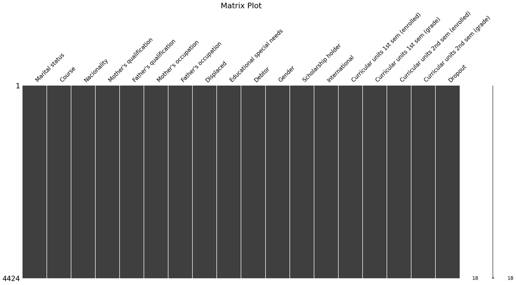

```python
import matplotlib.pylab as plt
import missingno as mn
import pandas as pd
import numpy as np

mn.matrix(df)
plt.title("Matrix Plot", fontsize=22)
plt.show()
```

Here's why we care about duplication considering some of the criterial taken by this data set: The chance that 2 student have the exact same information such as martial status, course, Nationality, and gender is fairly plausible given most of this information can have a level of systematic bias due to where and how the research is performed. But information such as parental, background, and grades related features (i.e. Mother’s Occupations, Father’s Occupation, 1st semester grades, 2nd semester grades) are statically improbable to be completely the same, especially if it spans over all features.

```python
# Find the duplicate instances (excluding the first occurrence)
idx = df.duplicated()

# Find the number of duplicate instances
num_duplicates = idx.sum()  # Sum of 'True' values gives the count of duplicates

print(num_duplicates)
```

```
15
```

Given that only 15 instances were found and within those duplications, there are only a few overlaps within those duplications, we decided that keeping all 15 instances in the data set was fine. For a dataset with 4424 total entries, 15 instances is only 0.339% of the data set, negligible to the entire dataset. Yes, the statistical chance of duplication in this research is very unlikely, but since 15 is such a small percentage of the total 4424, it isn't impossible 2 distinct people to have the same features either by shear chance or a divine joke by god. In worst case scenario, these 15 entries were simply entry errors; having 0.339% of the data count more than once won’t really affect the grand scheme of things, the consequence is insignificant.

```python
# Find the rows that are duplicated (excluding the first occurrence)
duplicate_rows = df[df.duplicated()]

print(duplicate_rows)
```

```
      Marital status  Course  Nacionality  Mother's qualification  \
1689               1     171            1                      37
1814               1    9070            1                       1
2253               1    9119            1                      34
2462               1     171            1                       3
2590               1    9003            1                      19
3160               1     171            1                      38
3347               1    9147            1                      37
3490               1     171            1                      37
3491               2    9991            1                      37
3536               1    9991            1                      37
3682               1    9991            1                      37
3717               1     171            1                      37
3839               1     171            1                      37
4033               1     171            1                       3
```

[output cut: 86 more lines]

Lastly, as you will see from the data visualization in the next section, even though the data set has no missing values, there are some irregularities with some of the values that might create issues for a machine learning model. An example would be the "Histogram of 1st Semester Grades" where you have a very high amount of 0s. There are some reasonable explanations for why there would be so many grades of 0 in the data set. So if a student doesn't even finish their first semester, or they are a transfer student, or they just straight up bombed their first semester, this could account for the 0s in the dataset. But due to the consistency and quantity of these data irregularities, we don’t want to be eliminating or imputing these data since that will most definitely change the overall results of the data set.

# 3. Data Visualization

## 3.1 Feature Distributions

```python
import pandas as pd
import matplotlib.pyplot as plt
import seaborn as sns

# Load the data
file_path = 'data.csv'
df = pd.read_csv(file_path)

# Drop unnecessary columns as per the existing code
drop_columns = ['Previous qualification','Previous qualification (grade)','Admission grade',
                'Daytime/evening attendance\t','Application mode', 'Application order',
                'Tuition fees up to date', 'Curricular units 1st sem (credited)',
                'Curricular units 1st sem (evaluations)', 'Curricular units 1st sem (approved)',
                'Curricular units 1st sem (without evaluations)', 'Curricular units 2nd sem (credited)',
                'Curricular units 2nd sem (evaluations)', 'Curricular units 2nd sem (approved)',
                'Curricular units 2nd sem (without evaluations)', 'Age at enrollment', 'GDP',
                'Inflation rate', 'Unemployment rate']
df = df.drop(drop_columns, axis=1)

# Rename target column to 'Dropout'
df = df.rename(columns={'Target': 'Dropout'})

# Replace content of 'Dropout' column to 'Graduate' and 'Dropout'
df.Dropout.replace([0, 1], ['Graduate', 'Dropout'], inplace=True)

# Set the style for better-looking plots
plt.style.use('seaborn-v0_8')

df.head()
```

|  | Marital status | Course | Nacionality | Mother's qualification | Father's qualification | Mother's occupation | Father's occupation | Displaced | Educational special needs | Debtor | Gender | Scholarship holder | International | Curricular units 1st sem (enrolled) | Curricular units 1st sem (grade) | Curricular units 2nd sem (enrolled) | Curricular units 2nd sem (grade) | Dropout |
| --- | --- | --- | --- | --- | --- | --- | --- | --- | --- | --- | --- | --- | --- | --- | --- | --- | --- | --- |
| 0 | 1 | 171 | 1 | 19 | 12 | 5 | 9 | 1 | 0 | 0 | 1 | 0 | 0 | 0 | 0.000000 | 0 | 0.000000 | Dropout |
| 1 | 1 | 9254 | 1 | 1 | 3 | 3 | 3 | 1 | 0 | 0 | 1 | 0 | 0 | 6 | 14.000000 | 6 | 13.666667 | Graduate |
| 2 | 1 | 9070 | 1 | 37 | 37 | 9 | 9 | 1 | 0 | 0 | 1 | 0 | 0 | 6 | 0.000000 | 6 | 0.000000 | Dropout |
| 3 | 1 | 9773 | 1 | 38 | 37 | 5 | 3 | 1 | 0 | 0 | 0 | 0 | 0 | 6 | 13.428571 | 6 | 12.400000 | Graduate |
| 4 | 2 | 8014 | 1 | 37 | 38 | 9 | 9 | 0 | 0 | 0 | 0 | 0 | 0 | 6 | 12.333333 | 6 | 13.000000 | Graduate |

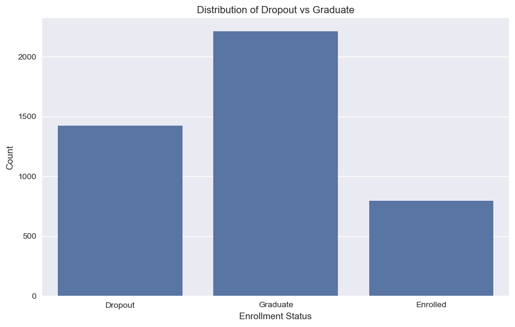

```
Dropout
Graduate    2209
Dropout     1421
Enrolled     794
Name: count, dtype: int64
```

```python
# 1. Distribution of Dropout vs Graduate (categorical)
plt.figure(figsize=(10, 6))
sns.countplot(x='Dropout', data=df)
plt.title('Distribution of Dropout vs Graduate')
plt.xlabel('Enrollment Status')
plt.ylabel('Count')
plt.show()

# output values
print(df['Dropout'].value_counts())
```

There is a very high percentage of dropouts -- greater than enrolled makes sense, but the dropout population being greater than half of the graduate students is interesting. This indicates that the dataset has a high dropout rate, which is important to consider going forward.

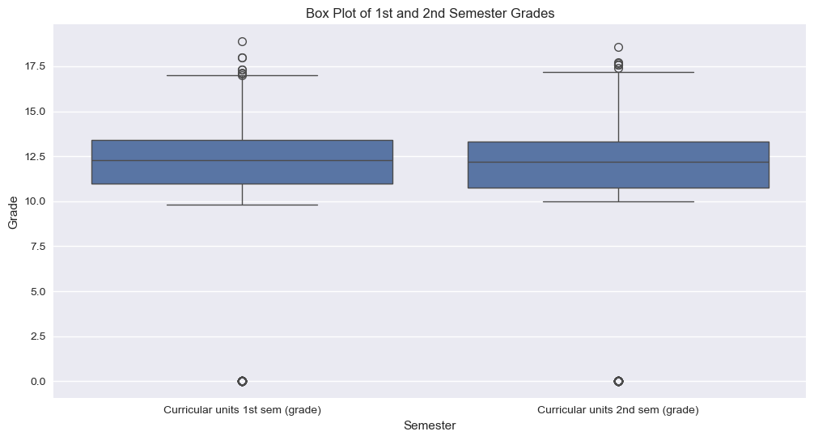

```
count    4424.000000
mean       10.640822
std         4.843663
min         0.000000
25%        11.000000
50%        12.285714
75%        13.400000
max        18.875000
Name: Curricular units 1st sem (grade), dtype: float64
count    4424.000000
mean       10.230206
std         5.210808
min         0.000000
25%        10.750000
50%        12.200000
75%        13.333333
max        18.571429
Name: Curricular units 2nd sem (grade), dtype: float64
```

```python
# 2. Box plot of 1st and 2nd semester grades
plt.figure(figsize=(12, 6))
df_melted = df.melt(value_vars=['Curricular units 1st sem (grade)', 'Curricular units 2nd sem (grade)'],
                    var_name='Semester', value_name='Grade')
sns.boxplot(x='Semester', y='Grade', data=df_melted)
plt.title('Box Plot of 1st and 2nd Semester Grades')
plt.xlabel('Semester')
plt.ylabel('Grade')
plt.show()


# output values
print(df['Curricular units 1st sem (grade)'].describe())
print(df['Curricular units 2nd sem (grade)'].describe())
```

The 1st and 2nd semester grades are similar across the total population, which is important to keep in mind when analyzing 1st semester to 2nd semester grade distributions for dropouts in particular. A large discrepancy between the 1st and 2nd semester grades for all students would decrease its importance when predicting dropout rates, but similarity between them means that if dropouts were to have lower grades in either semester (particularly the 2nd semester), it may be an important factor to consider.

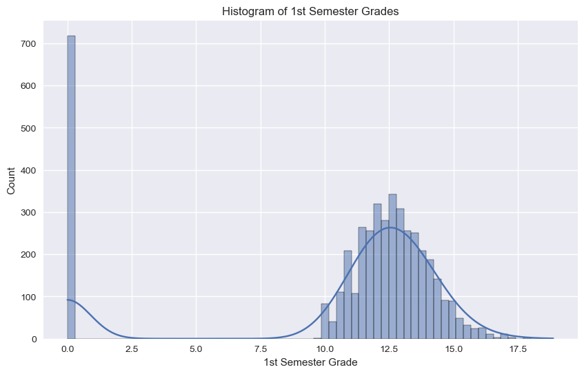

```
Grade distribution:
Curricular units 1st sem (grade)
0.000000     718
9.800000       1
10.000000     82
10.166667      1
10.200000      8
            ...
17.111111      1
17.125000      1
17.333333      2
18.000000      2
18.875000      1
Name: count, Length: 805, dtype: int64

Basic statistics excluding 0 values:
count    3706.000000
mean       12.702373
std         1.346842
min         9.800000
25%        11.750000
50%        12.626786
75%        13.571429
max        18.875000
Name: Curricular units 1st sem (grade), dtype: float64
```

```python
# 3. Histogram of 1st Semester Grades (including 0 grades)
plt.figure(figsize=(10, 6))
sns.histplot(data=df, x='Curricular units 1st sem (grade)', kde=True)
plt.title('Histogram of 1st Semester Grades')
plt.xlabel('1st Semester Grade')
plt.ylabel('Count')
plt.show()

# Print value counts
grade_counts = df['Curricular units 1st sem (grade)'].value_counts().sort_index()
print("Grade distribution:")
print(grade_counts)

# Print some basic statistics excluding 0 values
print("\nBasic statistics excluding 0 values:")
print(df[df['Curricular units 1st sem (grade)'] != 0]['Curricular units 1st sem (grade)'].describe())
```

Many students have 0 for 1st semester grades (they probably didn't finish or attend 1st semester) and imputation would be necessary here. We could fill in this data using mean/median imputation, regression imputation based on features, etc.

Average 1st semester grades (excluding 0 values) is 12.7, which will be useful to compare against the average 1st semester grade of dropouts for predicition models, as this is usually a pivotal point in determining whether a student is at risk of dropping out.

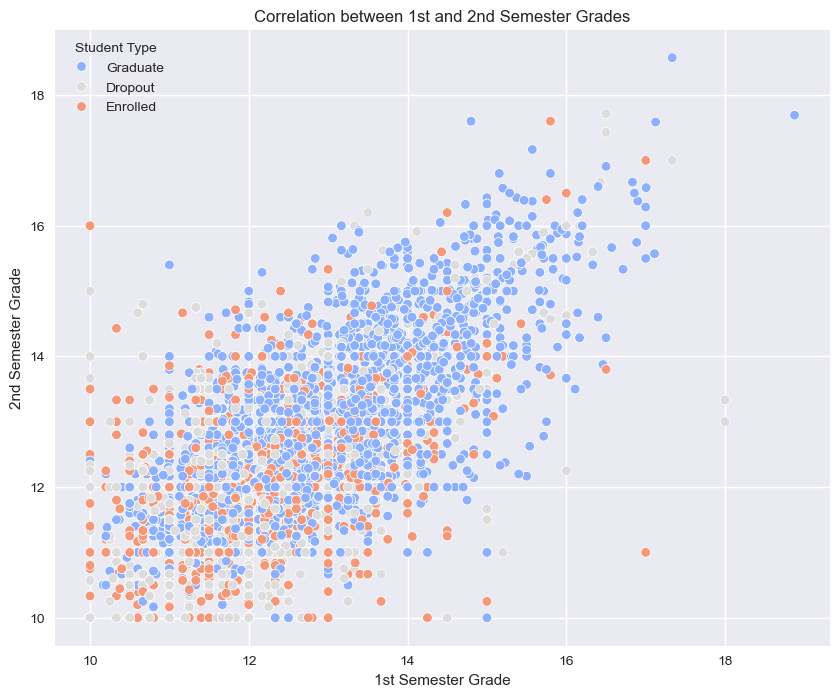

```
Correlation between 1st and 2nd semester grades: 0.68

Average grades for dropouts and graduates:
              Curricular units 1st sem (grade)  \
Student Type
Dropout                              12.180014
Enrolled                             12.234710
Graduate                             13.100297

              Curricular units 2nd sem (grade)
Student Type
Dropout                              12.098971
Enrolled                             12.161531
Graduate                             13.143643

Percentage of students who improved their grades: 43.05%

Basic statistics for 1st semester grades:
count    3512.000000
mean       12.749740
std         1.328439
min        10.000000
25%        11.800000
50%        12.666667
75%        13.600000
max        18.875000
Name: Curricular units 1st sem (grade), dtype: float64

Basic statistics for 2nd semester grades:
count    3512.000000
mean       12.745799
std         1.371640
min        10.000000
25%        11.750000
50%        12.666667
75%        13.666667
max        18.571429
Name: Curricular units 2nd sem (grade), dtype: float64
```

```python
# 4. Correlation between 1st and 2nd semester grades
plt.figure(figsize=(10, 8))

# Ensure that grades are properly converted to numeric for both semesters
df['Curricular units 1st sem (grade)'] = pd.to_numeric(df['Curricular units 1st sem (grade)'], errors='coerce')
df['Curricular units 2nd sem (grade)'] = pd.to_numeric(df['Curricular units 2nd sem (grade)'], errors='coerce')

# Filter out the rows where both grades are 0 (no meaningful correlation)
df_filtered = df[(df['Curricular units 1st sem (grade)'] != 0) &
                 (df['Curricular units 2nd sem (grade)'] != 0)]

# Rename 'Dropout' to 'Student Type' for clarity
df_filtered = df_filtered.rename(columns={'Dropout': 'Student Type'})

# Plot filtered data
sns.scatterplot(x='Curricular units 1st sem (grade)', y='Curricular units 2nd sem (grade)',
                hue='Student Type', data=df_filtered, palette='coolwarm')

plt.title('Correlation between 1st and 2nd Semester Grades')
plt.xlabel('1st Semester Grade')
plt.ylabel('2nd Semester Grade')
plt.show()

# Calculate correlation
correlation = df_filtered['Curricular units 1st sem (grade)'].corr(df_filtered['Curricular units 2nd sem (grade)'])
print(f"Correlation between 1st and 2nd semester grades: {correlation:.2f}")

# Calculate average grades for dropouts and graduates
avg_grades = df_filtered.groupby('Student Type')[['Curricular units 1st sem (grade)', 'Curricular units 2nd sem (grade)']].mean()
print("\nAverage grades for dropouts and graduates:")
print(avg_grades)

# Calculate percentage of students who improved their grades
improved = (df_filtered['Curricular units 2nd sem (grade)'] > df_filtered['Curricular units 1st sem (grade)']).mean() * 100
print(f"\nPercentage of students who improved their grades: {improved:.2f}%")

# Print some basic statistics
print("\nBasic statistics for 1st semester grades:")
print(df_filtered['Curricular units 1st sem (grade)'].describe())
print("\nBasic statistics for 2nd semester grades:")
print(df_filtered['Curricular units 2nd sem (grade)'].describe())
```

There is relatively strong positive correlation between 1st and 2nd semester grades in this dataset across the board. This removes comparing 1st and 2nd semester grades as a way of predicting student dropout risk because since they are so similar, we won't be able to extract any new useful information if we had just used one dataset (eg. 1st semester grades).

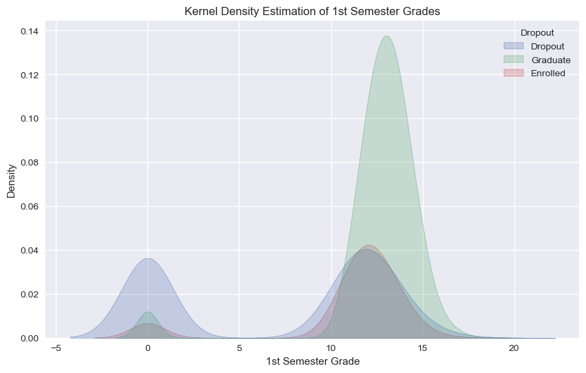

```python
# 5. Kernel Density Estimation of 1st Semester Grades
plt.figure(figsize=(10, 6))
sns.kdeplot(data=df, x='Curricular units 1st sem (grade)', hue='Dropout', fill=True)
plt.title('Kernel Density Estimation of 1st Semester Grades')
plt.xlabel('1st Semester Grade')
plt.ylabel('Density')
plt.show()
```

The value **0** first semester grade distribution shows that there are more dropouts with missing first semester grades in this dataset than any other category, showing that a large number of dropouts probably didn't even finish their first semester.

This shows that even some high performing students are at risk of dropping out. Overall, students with lower first semester grades are at a higher risk of dropping out, which is expected.

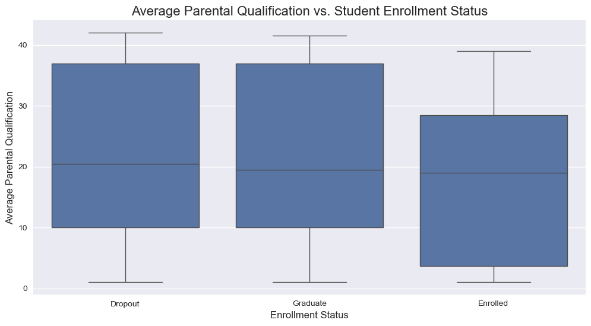

```
           count       mean        std  min     25%   50%   75%   max
Dropout
Dropout   1421.0  21.859254  13.746225  1.0  10.000  20.5  37.0  42.0
Enrolled   794.0  19.271411  13.437434  1.0   3.625  19.0  28.5  39.0
Graduate  2209.0  20.905613  13.424373  1.0  10.000  19.5  37.0  41.5
```

```python
# 6. Dropouts Based on Parental Qualification
# Calculate average parental qualification
df['Avg_Parent_Qual'] = (df['Mother\'s qualification'] + df['Father\'s qualification']) / 2

# Create a new figure
plt.figure(figsize=(12, 6))

# Create a box plot
sns.boxplot(x='Dropout', y='Avg_Parent_Qual', data=df)

# Customize the plot
plt.title('Average Parental Qualification vs. Student Enrollment Status', fontsize=16)
plt.xlabel('Enrollment Status', fontsize=12)
plt.ylabel('Average Parental Qualification', fontsize=12)

# Show the plot
plt.show()

# Print some statistics
print(df.groupby('Dropout')['Avg_Parent_Qual'].describe())
```

Dropout students actually had the highest average parental qualification, which is unexpected. For this dataset, it is not a good indicator of dropout risk.

## 3.2 Questions and Visuals

##### 1. How does the distribution of dropout rates vary across different courses?

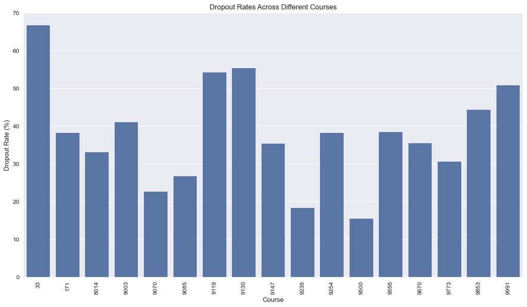

```
Top 3 courses with most dropout students:
Course
33      66.666667
9130    55.319149
9119    54.117647
Name: Dropout, dtype: float64

Top 3 courses with least dropout students:
Course
9500    15.404700
9238    18.309859
9070    22.566372
Name: Dropout, dtype: float64
```

```python
plt.figure(figsize=(15, 8))
dropout_rates = df.groupby('Course')['Dropout'].apply(lambda x: (x == 'Dropout').mean() * 100)
sns.barplot(x=dropout_rates.index, y=dropout_rates.values)
plt.title('Dropout Rates Across Different Courses')
plt.xlabel('Course')
plt.ylabel('Dropout Rate (%)')
plt.xticks(rotation=90)
plt.show()

print("Top 3 courses with most dropout students:")
print(dropout_rates.sort_values(ascending=False).head(3))
print("\nTop 3 courses with least dropout students:")
print(dropout_rates.sort_values().head(3))
```

There is a wide spread of dropout rates across different courses. For the courses with especially high dropout rates (over 50%), they would be useful for the retention office for a number of reasons:

1. Analyzing courses with high dropout rates can help identify common risk factors (e.g., course content, teaching methods, student demographics) that may be contributing to the high dropout rates.
2. High dropout rates may indicate that the course is particularly challenging. This information can help identify patterns or characteristics that contribute to student dropouts.
3. Understanding why certain courses have high dropout rates can help in designing targeted intervention strategies to reduce dropout rates.

##### 2. Is there a relationship between scholarship status and dropout rates?

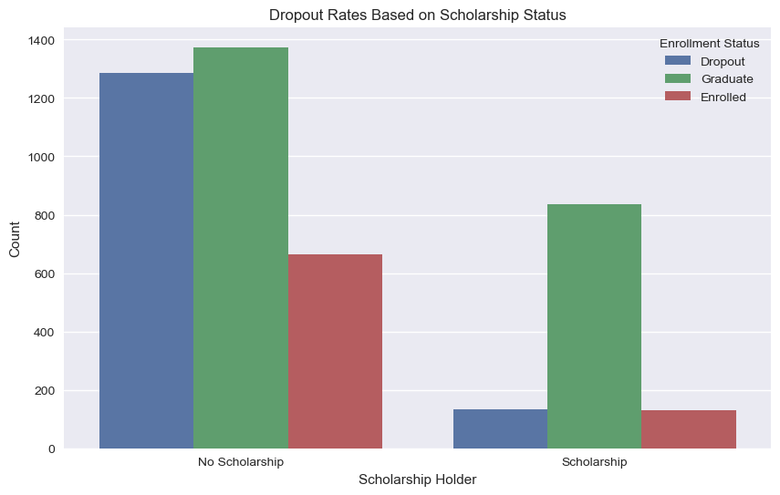

```
Dropout rates:
Scholarship holder
No Scholarship    38.706767
Scholarship       12.192903
Name: Dropout, dtype: float64
```

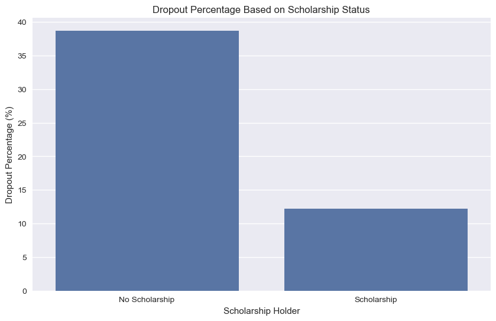

```
Dropout percentage against total number in the category:
Scholarship holder
No Scholarship    38.706767
Scholarship       12.192903
Name: count, dtype: float64
```

```python
plt.figure(figsize=(10, 6))
sns.countplot(x='Scholarship holder', hue='Dropout', data=df)
plt.title('Dropout Rates Based on Scholarship Status')
plt.xlabel('Scholarship Holder')
plt.ylabel('Count')
plt.legend(title='Enrollment Status')
plt.xticks([0, 1], ['No Scholarship', 'Scholarship'])
plt.show()

scholarship_dropout_rates = df.groupby('Scholarship holder')['Dropout'].apply(lambda x: (x == 'Dropout').mean() * 100)
print("Dropout rates:")
print(scholarship_dropout_rates.rename(index={0: 'No Scholarship', 1: 'Scholarship'}))

# Percentage of dropouts against the total students in each category
total_counts = df['Scholarship holder'].value_counts()
dropout_counts = df[df['Dropout'] == 'Dropout']['Scholarship holder'].value_counts()
dropout_percentage = (dropout_counts / total_counts) * 100

# Plot the dropout percentage
plt.figure(figsize=(10, 6))
sns.barplot(x=dropout_percentage.index, y=dropout_percentage.values)
plt.title('Dropout Percentage Based on Scholarship Status')
plt.xlabel('Scholarship Holder')
plt.ylabel('Dropout Percentage (%)')
plt.xticks([0, 1], ['No Scholarship', 'Scholarship'])
plt.show()

print("Dropout percentage against total number in the category:")
print(dropout_percentage.rename(index={0: 'No Scholarship', 1: 'Scholarship'}))
```

The first bar chart shows that there is significantly more students who dropout when they don't have any scholarships compared to students with a scholarship. This could potentially be useful for the retention office because it could signal a need to increase scholarship funds in order to decrease dropout rates.

However, this could be misleading because there probably is a lot more students without scholarship than with scholarship, therefore a better way to answer the question would be to look at the percentange of dropouts against number of students. But even the 2nd bar chart which shows the percentage of dropouts against the total number of students in that category, shows that there is a significantly higher percentage of students with no scholarship who drop out compared to students who dropout with scholarship.

##### 3. How do first semester grades correlate with dropout rates?

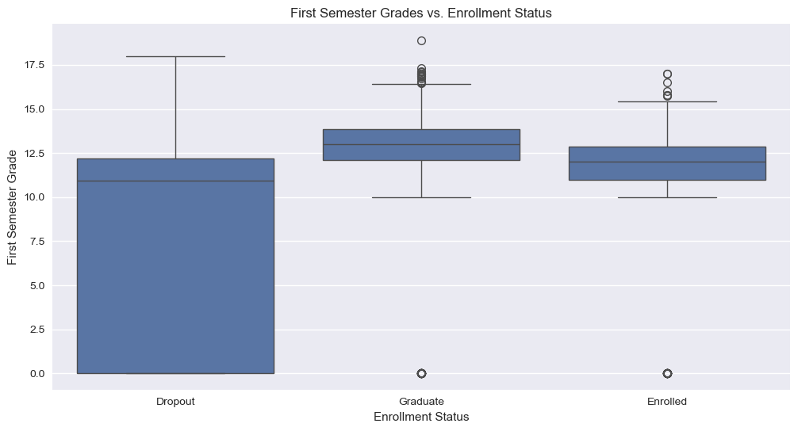

```
                    count       mean       std  min        25%        50%  \
Enrollment Status
Dropout            1421.0   7.256656  6.031120  0.0   0.000000  10.928571
Enrolled            794.0  11.125257  3.675084  0.0  11.000000  12.000000
Graduate           2209.0  12.643655  2.699027  0.0  12.121429  13.000000

                         75%     max
Enrollment Status
Dropout            12.200000  18.000
Enrolled           12.857143  17.000
Graduate           13.857143  18.875
```

```python
plt.figure(figsize=(12, 6))
sns.boxplot(x='Dropout', y='Curricular units 1st sem (grade)', data=df)
plt.title('First Semester Grades vs. Enrollment Status')
plt.xlabel('Enrollment Status')
plt.ylabel('First Semester Grade')
plt.show()

# Rename the 'Dropout' column to 'Enrollment Status' for clarity in the output
df_renamed = df.rename(columns={'Dropout': 'Enrollment Status'})
grade_stats = df_renamed.groupby('Enrollment Status')['Curricular units 1st sem (grade)'].describe()
print(grade_stats)
```

The boxplot indicates that the median grades for students who drop out are lower than students who have graduated or are currently enrolled. Using this data, the rention office can keep track of students who have grades less than or equal to the median dropout grade. Targeting these students will let the office know who to offer additional support to.

# 4. Exceptional Work

## UMAP Implementation

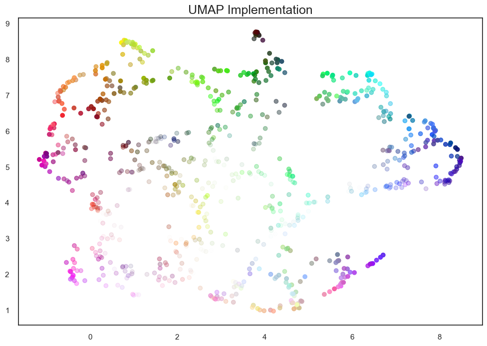

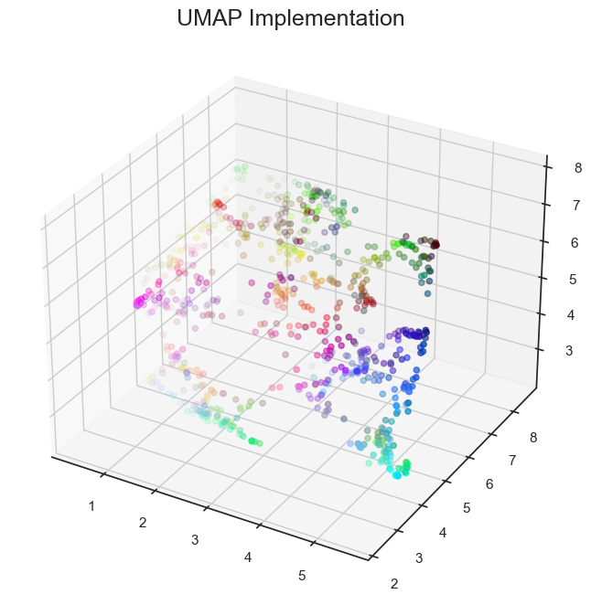

```python
# The following code was edited from the code provided in this Github: https://github.com/lmcinnes/umap/tree/master

import umap.umap_ as umap
import matplotlib.pyplot as plt
from ipywidgets import IntSlider, interact, FloatSlider

def draw_umap(n_neighbors=15, min_dist=0.1, n_components=2, metric='euclidean', title=''):
    fit = umap.UMAP(n_neighbors=n_neighbors,
                    min_dist=min_dist,
                    n_components=n_components,
                    metric=metric)
    u = fit.fit_transform(data)
    fig = plt.figure()
    if n_components == 1:
        ax = fig.add_subplot(111)
        ax.scatter(u[:,0], range(len(u)), c=data)
    if n_components ==2:
        ax = fig.add_subplot(111)
        ax.scatter(u[:,0], u[:,1], c=data)
    if n_components ==3:
        ax = fig.add_subplot(111, projection='3d')
        ax.scatter(u[:,0], u[:,1], u[:,2], c=data)
    plt.title(title, fontsize=18)
    # plt.colorbar(ax)


data = pd.read_csv('data.csv')

#rename target column to 'Dropout'
#data = data.rename(columns={'Target': 'Dropout'})
data.Target.replace(['Graduate', 'Dropout', 'Enrolled'], [0, 1, 2], inplace=True)

# assigns 4d colors to each of the data points. Used later when plotting
# the 2d graph of the data
sns.set_theme(style='white', rc={'figure.figsize':(12,8)})

labels = data.columns

#groups similar colors together
np.random.seed(42)
data = np.random.rand(800, 4)

# plots the graph in 2D and 3D
draw_umap(n_components=2, title='UMAP Implementation')
draw_umap(n_components=3, title='UMAP Implementation')

# The following code is for a neat interactive widget I made. Turns out, however, you can't compile an interactive
# widget into an HTML file. But I'm leaving the code anyways because I think it's neat :) -Melanie Cloud

#interact(draw_umap, title='UMAP Implementation', n_neighbors=IntSlider(min=5, max=50, step=1, value=15), min_dist=FloatSlider(min=0.001, max=0.5, step=.001, value=0.1), n_components=IntSlider(min=1, max=3, step=1, value=2))

# https://notebook.community/seewhydee/ntuphys_nb/jupyter_tutorial/jupyter_tutorial_02
# ^^^ Code for interactive widgets
```

Citation from the Github listed above.

@article{mcinnes2018umap-software, title={UMAP: Uniform Manifold Approximation and Projection}, author={McInnes, Leland and Healy, John and Saul, Nathaniel and Grossberger, Lukas}, journal={The Journal of Open Source Software}, volume={3}, number={29}, pages={861}, year={2018} }

### Explanation of UMAP dimensionality reduction methods

Dimensionality reduction is used to aid in visualizing and understanding the relationship between many variables in a dataset. When there are only a few variables (e.g. x and y on a traditional cartesian plane), it is easy to see the correlation between the two variables simply by graphing it. However, it becomes harder to visualize the relationship between variables when the number of variables increases above 3. Dimensionality reduction helps portray multi-dimensional variable relationships in a 1d, 2d, or 3d manner so that it is easier to see the relationship between many variables all at once.

The variable min_dist affects how closely points can be compressed together. Large values for min_dst will make the points more loosely clustered, causing the model to lose some detail and decrease the visibility of the global structure of the data.

The variable n_neighbors determines how globalized the clusters are. The more neighbors, the better global view one will have of the data. The fewer neighbors will result in a more localized view with more detail, but it will be more difficult to see the overall structure of the data set.